# Statistics in R

## Today's session:

- Analysis of variance (ANOVA) in R

## ANOVA

## ANOVA in R

```r
yields <- read.table("Data/yields.txt", sep = ";", header = TRUE)

summary(yields)
```

```
##      plotid           sand            clay            loam
##  Min.   : 1.00   Min.   : 6.00   Min.   : 3.00   Min.   : 9.0
##  1st Qu.: 3.25   1st Qu.: 7.25   1st Qu.:10.25   1st Qu.:13.0
##  Median : 5.50   Median : 9.50   Median :12.00   Median :14.5
##  Mean   : 5.50   Mean   : 9.90   Mean   :11.50   Mean   :14.3
##  3rd Qu.: 7.75   3rd Qu.:11.00   3rd Qu.:13.75   3rd Qu.:16.0
##  Max.   :10.00   Max.   :17.00   Max.   :17.00   Max.   :18.0
```

## ANOVA in R

```r
yields_tidy <- yields %>% gather(., key = soiltype, value = yield, -plotid)

yields_tidy_summary <- yields_tidy %>%
  group_by(soiltype) %>%
  summarize(mean = mean(yield))

p <- ggplot(yields_tidy, aes(x = soiltype, y = yield)) +
  geom_boxplot() +
  geom_hline(yintercept = mean(yields_tidy$yield), linetype = "dashed") +
  geom_point(data = yields_tidy_summary, aes(x = soiltype, y = mean), shape = 2)
```

## ANOVA in R

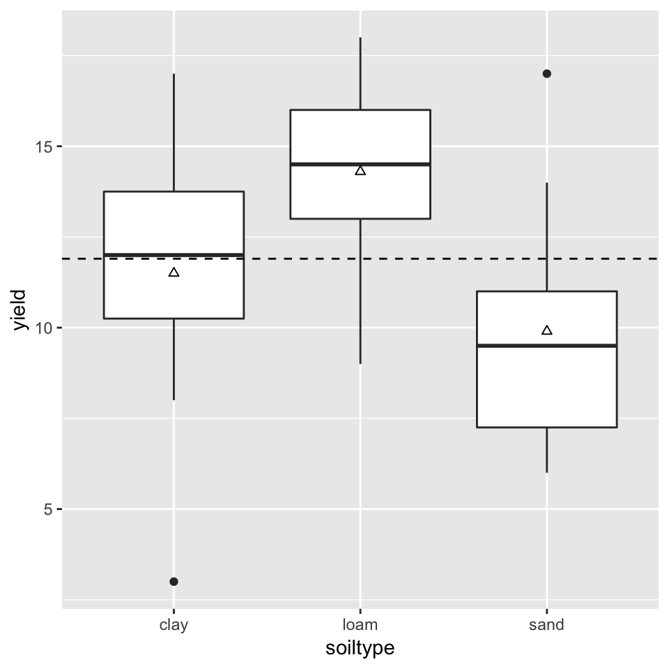

## ANOVA in R

ANOVA assumes variance homogeneity between groups. We can test this using a simple F-Test or using the Bartlett test (H0 is variance homogeneity):

```r
bartlett.test(x = yields_tidy$yield, g = yields_tidy$soiltype)
```

```
##
##  Bartlett test of homogeneity of variances
##
## data:  yields_tidy$yield and yields_tidy$soiltype
## Bartlett's K-squared = 1.2764, df = 2, p-value = 0.5283
```

We do not have strong evidence to reject H0, we hence assume variance homogeneity. As always, do not solely rely on test results. Plot your data and use common sense!

## ANOVA in R

We can fit an ANOVA model using the function `aov()`:

```r
fit <- aov(yield ~ soiltype, data = yields_tidy)
summary(fit)
```

```
##             Df Sum Sq Mean Sq F value Pr(>F)
## soiltype     2   99.2   49.60   4.245  0.025 *
## Residuals   27  315.5   11.69
## ---
## Signif. codes:  0 '***' 0.001 '**' 0.01 '*' 0.05 '.' 0.1 ' ' 1
```

## ANOVA in R

Remember that the ANOVA is just a special case of a linear model:

```r
summary.lm(fit)
```

```
##
## Call:
## aov(formula = yield ~ soiltype, data = yields_tidy)
##
## Residuals:
##    Min     1Q Median     3Q    Max
##   -8.5   -1.8    0.3    1.7    7.1
##
## Coefficients:
##              Estimate Std. Error t value Pr(>|t|)
## (Intercept)    11.500      1.081  10.638  3.7e-11 ***
## soiltypeloam    2.800      1.529   1.832   0.0781 .
## soiltypesand   -1.600      1.529  -1.047   0.3046
## ---
## Signif. codes:  0 '***' 0.001 '**' 0.01 '*' 0.05 '.' 0.1 ' ' 1
##
## Residual standard error: 3.418 on 27 degrees of freedom
## Multiple R-squared:  0.2392, Adjusted R-squared:  0.1829
## F-statistic: 4.245 on 2 and 27 DF,  p-value: 0.02495
```

## ANOVA in R

Comparing it to the mean of the yields:

```r
yields_tidy_summary
```

```
## # A tibble: 3 x 2
##   soiltype  mean
##   <chr>    <dbl>
## 1 clay      11.5
## 2 loam      14.3
## 3 sand       9.9
```

## ANOVA in R

Similar to last week, we have to check the model assumptions by plotting the residuals over the fitted values:

```r
yields_residuals_fitted <- data.frame(residuals = residuals(fit),
                                      fitted = fitted(fit))

p <- ggplot(data = yields_residuals_fitted,
       aes(x = fitted, y = residuals)) +
  geom_point() +
  geom_hline(yintercept = 0)
```

## ANOVA in R

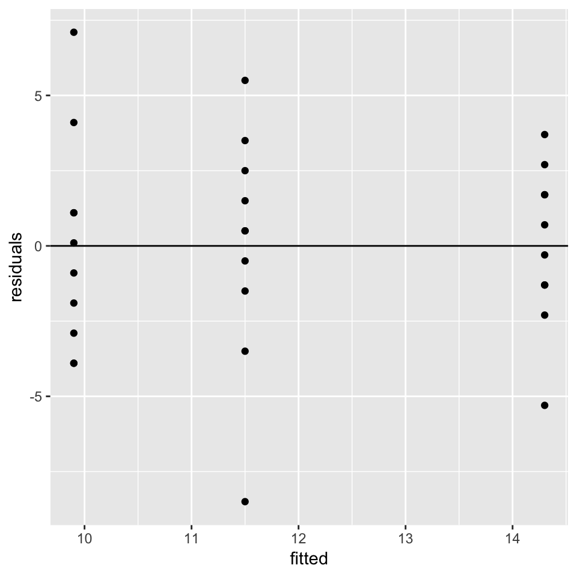

## ANOVA in R

The assumption of normally distributed residuals can be checked using a qq-plot:

```r
yields_residuals_fitted <- yields_residuals_fitted %>%
  mutate(residuals_ztrans = (residuals - mean(residuals)) / sd(residuals))

p <- ggplot(yields_residuals_fitted, aes()) +
  stat_qq(aes(sample = residuals_ztrans)) +
  geom_abline(intercept = 0, slope = 1)
```

## ANOVA in R

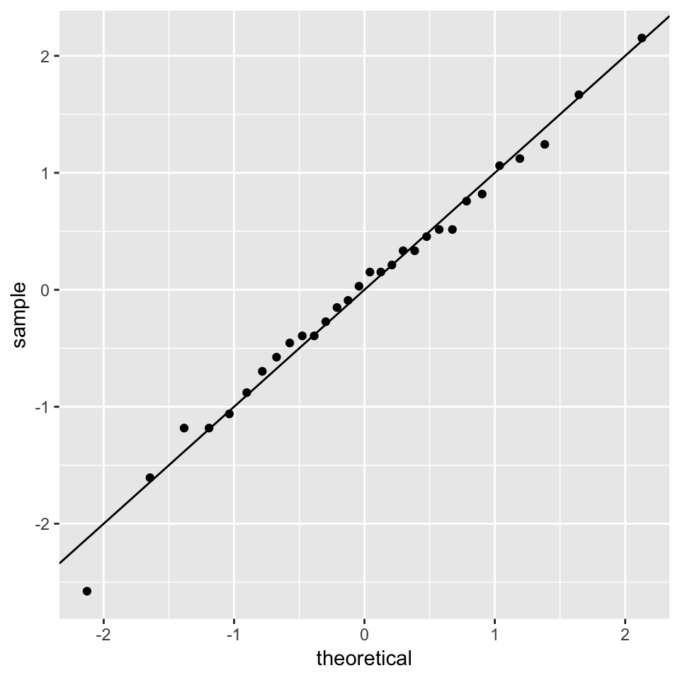

## ANOVA in R

We can extract the group-means using the `model.tables()` function:

```r
model.tables(fit, type = "means")
```

```
## Tables of means
## Grand mean
##
## 11.9
##
##  soiltype
## soiltype
## clay loam sand
## 11.5 14.3  9.9
```

## ANOVA in R

Or we can extract the effect sizes, that is the differences in means, which is often more interesting:

```r
model.tables(fit, type = "effects")
```

```
## Tables of effects
##
##  soiltype
## soiltype
## clay loam sand
## -0.4  2.4 -2.0
```

## ANOVA in R

We already know that at least two soiltypes have significantely different yields. However, it would be good to know which differences are significant. Therefore, we use **Tukey's ‘Honest Significant Difference’ Method**:

```r
TukeyHSD(fit)
```

```
##   Tukey multiple comparisons of means
##     95% family-wise confidence level
##
## Fit: aov(formula = yield ~ soiltype, data = yields_tidy)
##
## $soiltype
##           diff        lwr        upr     p adj
## loam-clay  2.8 -0.9903777  6.5903777 0.1785489
## sand-clay -1.6 -5.3903777  2.1903777 0.5546301
## sand-loam -4.4 -8.1903777 -0.6096223 0.0204414
```

## Correcting for multiple testing

Why do we need to correct for multiple testing? Let's have a look at XKCD: https://xkcd.com/882/

## Correcting for multiple testing

By repeating a NHST on one same sample, we increase our change of making a false-positive discovery (alpha-error).

Consider a significance level of p<0.05. When doing 20 tests on the same sample, we would expect one significant results just by chance.

There are several methods to correct for this issue, of which TukeyHSD is only one (see `?p.adjust` for further info).

The number of hitting a false-positive increases with number of comparisons, which is not only determined by the number of tests, but also the number of data-processing steps you perform. This problem is known as the *Garden of Forking Pathes* and described in detaily here: http://www.stat.columbia.edu/~gelman/research/unpublished/p_hacking.pdf

## ANOVA in R

We can plot the differences in means (effect sizes) using points and errorbars:

```r
tukey <- as.data.frame(TukeyHSD(fit)$soiltype)
tukey$soiltype <- rownames(tukey)

p <- ggplot(tukey, aes(x = soiltype, y = diff)) +
  geom_point() +
  geom_errorbar(aes(ymin = lwr, ymax = upr), width = 0.25) +
  geom_hline(yintercept = 0) +
  labs(x = "Soiltype", y = "Differnece in means")
```

## ANOVA in R

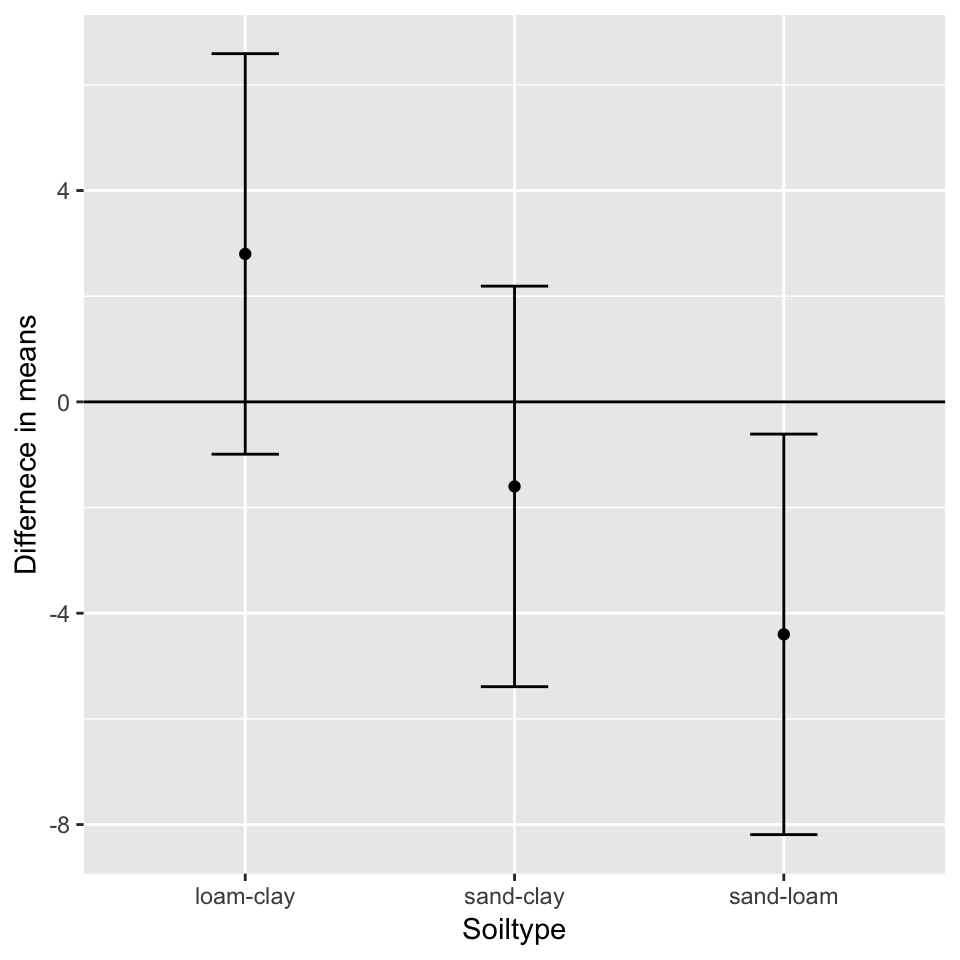